# 107.106 AKSTA Statistical Computing

Control Statements

Fabian Schroeder

SS 2018

## Control Statements

R code is usually executed in a sequential way - one line after another. However, there are methods to control the flow of commands. These are called control statements and can be categorized into conditional control used for branching statements (`if/else`, and `switch`) and repetitive control used for looping statements (`for`, `while`, `repeat`).

The `function` construct, itself, constitutes a different way to affect flow of commands and will be discussed in a later chapter.

### `if/else`

The `if/else` statement conditionally evaluates two statements. The formal syntax is

```r
if ( condition )
  expression 1
else
  expression 2
```

The condition is an expression which evaluates to a single logical value. If the condition is TRUE then the first expression is evaluated; otherwise the second expression is evaluated. The `if/else` statement returns, as its value, the value of the expression that was selected. The `else` statement is optional.

The `if/else` statements can be nested.

```r
if ( condition 1 ) {
  expression 1
} else if ( condition 2 ) {
  expression 2
} else if ( condition 3 ) {
  expression 3
} else
  expression 4
```

Let us look at a first trivial example which prints to the console depending on the sign of a number.

```r
n <- 12

if (n < 0) {
  print("n is negative!")
} else if (n == 0) {
  print("n is 0!")
} else {
  print("n is positive!")
}
```

```
## [1] "n is positive!"
```

There also exists an `ifelse()` function. The basic syntax is

```r
ifelse(condition, 'yes' , 'no')
```

This function is used when expression is a vector. The result is then a vector of same length as expression and has as corresponding entry the value of `yes` if expression is `TRUE`, of `no` if expression is `FALSE` and missing values in expression stay missing values. Note that `ifelse` will try to coerce the expression to logical if it is not. Also the attributes from expression will be kept and only the entries replaced.

```r
ifelse(c(1, 4, 2, -1, -2) < 0, "negative", "positive")
```

```
## [1] "positive" "positive" "positive" "negative" "negative"
```

### `switch`

A `switch` statement allows a variable to be tested for equality against a list of values. The syntax is

```r
switch (expression, case1, case2, case3, ...)
```

First, the condition is evaluated and matched to the cases. The condition must evaluate to a number or a character string. In case it evaluates to a character string the cases must be named.

```r
centre <- function(x, type) {
  switch(type,
         mean = mean(x),
         median = median(x),
         trimmed = mean(x, trim = .1))
}
```

### Looping

R has three statements that provide explicit looping. They are `for`, `while` and `repeat`. `for` is used when the number of loops is known a priori whereas `while` and `repeate` can be used when the number of loops is determined within the control statement and is, thus, not known a priori. The difference between `while` and `repeat` lies in the position of the condtion. In a `while` statement the condition is at the top of the statement whereas in a `repeat` statement the condition is usually at the end.

The value returned by a loop statement is always `NULL` and is returned invisibly.

There are two built-in constructs, `next` and `break`, which provide additional control over the evaluation. The `break` statement causes an exit from the innermost loop that is currently being executed. This is the only way to terminate `repeat` loops.

The `next` statement immediately causes control to return to the start of the loop. The `next` iteration of the loop (if there is one) is then executed. No statement below `next` in the current loop is evaluated.

R provides other functions for implicit looping such as tapply, apply, and lapply. In addition many operations, especially arithmetic ones, are vectorized so you may not need to use a loop. There are two statements that can be used to explicitly control looping.

#### Example: The Fibonacci Series

In mathematics, the Fibonacci numbers are the numbers in an integer sequence characterized by the fact that every number after the first two is the sum of the two preceding ones.

1, 1, 2, 3, 5, 8, 13, 21, 34, 55, 89, 144, …

The significance of this sequence lies in the fact that the ratio of the last two elements converges to the golden ratio, which is widely used in architecture and arts. The calculation of the Fibonacci series will provide an interesting example for excercising the following looping statements.

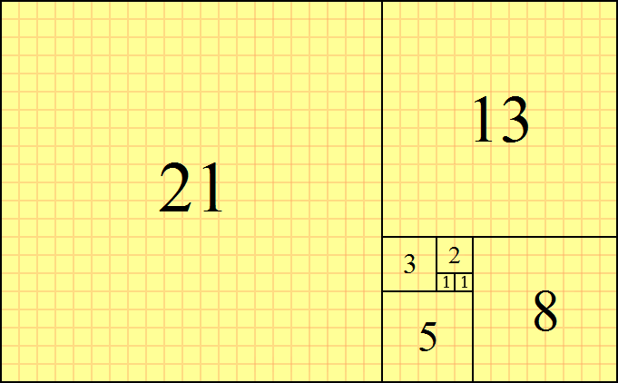

### `for`

The syntax of the for loop is

```r
for ( variable in sequence )
 {
  expression
 }
```

where `sequence` can be either a vector or a list. For each element in `sequence` the variable name is set to the value of that element and the expressions are evaluated. A side effect is that the variable name still exists after the loop has concluded and it has the value of the last element of vector that the loop was evaluated for.

```r
for (i in seq(1:10)) {
  print(i)
  if (i %% 5 ==0 ) break
}
```

```
## [1] 1
## [1] 2
## [1] 3
## [1] 4
## [1] 5
```

> Excercise 1 : Calculate the n-th element of the Fibonacci series using the for() loop

```r
fibo <- vector(mode = "numeric", length = n)
fibo[1] <- 1
fibo[2] <- 1

for (i in 3:n) {
  fibo[i] <- fibo[i-1] + fibo[i-2]
}
```

### `while`

The while statement is very similar to the repeat statement. The syntax of the while loop is

```r
while ( condition ) expression
```

where the `expression` is evaluated if the value of the condition is `TRUE`. This process continues until `condition` evaluates to `FALSE`. Thus, in order to avoid infinite looping the condition must be modified during each run of the expressions.

Let us look at a trivial example which prints all integers smaller than 6.

```r
i <- 1

while(i < 6) {
  print(i)
  i <- i + 1
}
```

```
## [1] 1
## [1] 2
## [1] 3
## [1] 4
## [1] 5
```

> Excercise 2 : Calculate the largest Fibonacci number smaller than 1000 using the while() loop. Since it is not a priori clear how many Fibonacci numbers under 1000 there are, this is a good example for the use of the `while` loop.

```r
fibo.new <- c(1,1)

while (fibo.new[2] < 1000) {
  fibo.old <- fibo.new
  fibo.new[1] <- fibo.old[2]
  fibo.new[2] <- fibo.old[1] + fibo.old[2]
}

fibo.new[1]
```

```
## [1] 987
```

### `repeat`

The `repeat` statement causes repeated evaluation of the body until a break is specifically requested. This means that you need to be careful when using repeat because of the danger of an infinite loop. The syntax of the repeat loop is

```r
repeat expression
```

When using `repeat`, expression must be a grouped expression. You need to both perform some computation and test whether or not to break from the loop. This usually requires at least two expressions.

```r
i <- 1
repeat {
  print(i)
  i <- i + 1
  if (i == 6) break
}
```

```
## [1] 1
## [1] 2
## [1] 3
## [1] 4
## [1] 5
```

> Excercise 3 : Calculate the largest Fibonacci number smaller than 1000 using the repeat() loop.

```r
fibo.new <- c(1,1)

repeat {
  fibo.old <- fibo.new
  fibo.new[1] <- fibo.old[2]
  fibo.new[2] <- fibo.old[1] + fibo.old[2]
  if (fibo.new[2] > 1000) break
}

fibo.new[1]
```

```
## [1] 987
```